# Data Wrangling

Melinda K. Higgins, PhD.

September 13, 2017

## Data Wrangling

For today’s lesson, you will want to download/make a copy of the Github repository https://github.com/melindahiggins2000/N736Fall2017_lesson06. This repo contains 3 datasets we will be working with in the exercises below:

- `dataA.csv` - has 3 variables (var1, var2, var3) and 6 subjects (1,2,3,5,8,9)
- `dataB.csv` - has 3 variables: 2 same and 1 different than `dataA` (var1, var2, var4) and 6 more subjects (11,12,14,15,17,18)
- `dataC.csv` - has 3 more variables (var5, var6, var7) and 6 subjects (1,2,3,4,7,10) some in common with `dataA` and some different

Lesson 05 covered:

- merging;
- joining;
- stacking; and
- concatenating 2 datasets together.

For Lesson 06 we’ll cover:

- adding labels and other notations
- recoding

In future lessons, we’ll also discuss:

- manipulating data types
- switching from numeric to character and back
- handling dates and times
- handling `factors` in `R` specifically - but in SAS (and in SPSS), numeric variables assumed to be continuous are modeled differently than numeric variables treated as “factors” (i.e. ordinal or categorical data represented numerically).

## Adding Labels and Other Notations

It can sometimes be helpful to add a label to your dataset or to your variables.

In `R` you can add a comment on your dataset which can then be pulled up using the `attributes()` function, which could be used later in a title or other text function.

**R CODE**

```r
library(readr)
library(knitr)
dataA <- read_csv("dataA.csv")
dataB <- read_csv("dataB.csv")

comment(dataA) <- "This is a comment on dataset dataA"
comment(dataB) <- "This is a comment on dataset dataB"

attributes(dataA)
```

```
## $names
## [1] "id"   "var1" "var2" "var3"
##
## $class
## [1] "tbl_df"     "tbl"        "data.frame"
##
## $row.names
## [1] 1 2 3 4 5 6
##
## $spec
##
## $comment
## [1] "This is a comment on dataset dataA"
```

```r
attributes(dataB)
```

```
## $names
## [1] "id"   "var1" "var2" "var4"
##
## $class
## [1] "tbl_df"     "tbl"        "data.frame"
##
## $row.names
## [1] 1 2 3 4 5 6
##
## $spec
##
## $comment
## [1] "This is a comment on dataset dataB"
```

I could use the result of the `attributes()` function to print out info on `dataA`.

```r
print(paste("Here are the details on dataset dataA:",
            attributes(dataA)$comment))
```

```
## [1] "Here are the details on dataset dataA: This is a comment on dataset dataA"
```

**SAS Code**

Load `dataA` and `dataB`.

```
* ======================================;
* load dataA;
* ======================================;
proc import datafile='C:\MyGithub\N736Fall2017_lesson05\dataA.csv'
  out=dataA dbms=csv;
run;

* ======================================;
* load dataB;
* ======================================;
proc import datafile='C:\MyGithub\N736Fall2017_lesson05\dataB.csv'
  out=dataB dbms=csv;
run;
```

In `SAS` it is possible to add a comment about the dataset, but this only shows up as a note in output like `PROC CONTENTS`.

```
data dataAcomment (label="This is a comment on dataA");
  set dataA;
run;

proc contents data=dataAcomment; run;
```

| Data Set Name | WORK.DATAACOMMENT | Observations | 6 |
| --- | --- | --- | --- |
| Member Type | DATA | Variables | 4 |
| Engine | V9 | Indexes | 0 |
| Created | 09/13/2017 11:47:11 | Observation Length | 32 |
| Last Modified | 09/13/2017 11:47:11 | Deleted Observations | 0 |
| Protection |  | Compressed | NO |
| Data Set Type |  | Sorted | NO |
| Label | This is a comment on dataA |  |  |
| Data Representation | WINDOWS_64 |  |  |
| Encoding | wlatin1 Western (Windows) |  |  |

| Engine/Host Dependent Information |  |
| --- | --- |
| Data Set Page Size | 65536 |
| Number of Data Set Pages | 1 |
| First Data Page | 1 |
| Max Obs per Page | 2039 |
| Obs in First Data Page | 6 |
| Number of Data Set Repairs | 0 |
| ExtendObsCounter | YES |
| Filename | C:Temporary Files_TD12532_SON-HIGGINS_.sas7bdat |
| Release Created | 9.0401M1 |
| Host Created | X64_8PRO |

| Alphabetic List of Variables and Attributes # | Alphabetic List of Variables and Attributes Variable | Alphabetic List of Variables and Attributes Type | Alphabetic List of Variables and Attributes Len | Alphabetic List of Variables and Attributes Format | Alphabetic List of Variables and Attributes Informat |
| --- | --- | --- | --- | --- | --- |
| 1 | id | Num | 8 | BEST12. | BEST32. |
| 2 | var1 | Num | 8 | BEST12. | BEST32. |
| 3 | var2 | Char | 1 | $1. | $1. |
| 4 | var3 | Num | 8 | BEST12. | BEST32. |

### adding labels and levels for `factors` in `R`

**R Code**

For `var` which has 5-point LiKert scale data coded from 1 to 5, let’s assume it should have the following labeling and interpretation:

```
1 = "strongly disagree"
2 = "disagree"
3 = "neutral"
4 = "agree"
5 = "strongly agree"
```

Also notice the changes in the “class”/“variable type” when we make `var1` a factor.

```r
kable(dataA)
```

| id | var1 | var2 | var3 |
| --- | --- | --- | --- |
| 1 | 3 | m | 45 |
| 2 | 3 | m | 44 |
| 3 | 2 | f | 34 |
| 5 | 4 | f | 38 |
| 8 | 1 | m | 41 |
| 9 | 5 | f | 39 |

```r
class(dataA$var1)
```

```
[1] "integer"
```

```r
typeof(dataA$var1)
```

```
[1] "integer"
```

```r
is.numeric(dataA$var1)
```

```
[1] TRUE
```

```r
dataA$var1 <- factor(dataA$var1,
                     levels=c(1,2,3,4,5),
                     labels=c("strongly disagree",
                              "disagree", "neutral",
                              "agree","strongly agree"))

kable(dataA)
```

| id | var1 | var2 | var3 |
| --- | --- | --- | --- |
| 1 | neutral | m | 45 |
| 2 | neutral | m | 44 |
| 3 | disagree | f | 34 |
| 5 | agree | f | 38 |
| 8 | strongly disagree | m | 41 |
| 9 | strongly agree | f | 39 |

```r
class(dataA$var1)
```

```
[1] "factor"
```

```r
typeof(dataA$var1)
```

```
[1] "integer"
```

```r
is.numeric(dataA$var1)
```

```
[1] FALSE
```

We can also apply better labeling for gender `var2` which is currently a character variable coed as “m” or “f”.

```r
kable(dataA)
```

| id | var1 | var2 | var3 |
| --- | --- | --- | --- |
| 1 | neutral | m | 45 |
| 2 | neutral | m | 44 |
| 3 | disagree | f | 34 |
| 5 | agree | f | 38 |
| 8 | strongly disagree | m | 41 |
| 9 | strongly agree | f | 39 |

```r
class(dataA$var2)
```

```
[1] "character"
```

```r
typeof(dataA$var2)
```

```
[1] "character"
```

```r
is.numeric(dataA$var2)
```

```
[1] FALSE
```

```r
dataA$var2 <- factor(dataA$var2,
                     levels=c("m","f"),
                     labels=c("male","female"))

kable(dataA)
```

| id | var1 | var2 | var3 |
| --- | --- | --- | --- |
| 1 | neutral | male | 45 |
| 2 | neutral | male | 44 |
| 3 | disagree | female | 34 |
| 5 | agree | female | 38 |
| 8 | strongly disagree | male | 41 |
| 9 | strongly agree | female | 39 |

```r
class(dataA$var2)
```

```
[1] "factor"
```

```r
typeof(dataA$var2)
```

```
[1] "integer"
```

```r
is.numeric(dataA$var2)
```

```
[1] FALSE
```

### using `SAS` formats

**SAS Code**

Create some formats for likert scale variables and for the gender character variable.

```
proc format;
  value likert
    1='strongly disagree'
    2='disagree'
    3='neutral'
      4='agree'
      5='strongly agree';
  value $gender
    'm'='male'
    'f'='female';
run;
```

See what it looks like without the format applied.

```
proc print data=dataA; run;
```

| Obs | id | var1 | var2 | var3 |
| --- | --- | --- | --- | --- |
| 1 | 1 | 3 | m | 45 |
| 2 | 2 | 3 | m | 44 |
| 3 | 3 | 2 | f | 34 |
| 4 | 5 | 4 | f | 38 |
| 5 | 8 | 1 | m | 41 |
| 6 | 9 | 5 | f | 39 |

Apply the format to a new dataset `dataA2` for the `var1` variable.

```
data dataA2;
  set dataA;
  format var1 likert.;
run;

proc print data=dataA2; run;
```

| Obs | id | var1 | var2 | var3 |
| --- | --- | --- | --- | --- |
| 1 | 1 | neutral | m | 45 |
| 2 | 2 | neutral | m | 44 |
| 3 | 3 | disagree | f | 34 |
| 4 | 5 | agree | f | 38 |
| 5 | 8 | strongly disagree | m | 41 |
| 6 | 9 | strongly agree | f | 39 |

You don’t have to use the format in a `DATA` step, you can simply use it when you need it, such as within a proc print statement to get the formatting you want in the output. Let’s use the `format` statement here when we print the data table for `dataB`.

```
proc print data=dataB;
  format var2 $gender.;
  run;
```

| Obs | id | var1 | var2 | VAR4 |
| --- | --- | --- | --- | --- |
| 1 | 11 | 4 | female | 0 |
| 2 | 12 | 4 | male | 6 |
| 3 | 14 | 2 | male | 4 |
| 4 | 15 | 3 | female | 7 |
| 5 | 17 | 1 | female | 8 |
| 6 | 18 | 5 | male | 5 |

```
* run a frequency table without formatting;

proc freq data=dataB;
  tables var2;
  run;

* add the formatting for the table;

proc freq data=dataB;
  format var2 $gender.;
  tables var2;
  run;
```

| var2 | Frequency | Percent | Cumulative Frequency | Cumulative Percent |
| --- | --- | --- | --- | --- |
| f | 3 | 50.00 | 3 | 50.00 |
| m | 3 | 50.00 | 6 | 100.00 |

| var2 | Frequency | Percent | Cumulative Frequency | Cumulative Percent |
| --- | --- | --- | --- | --- |
| female | 3 | 50.00 | 3 | 50.00 |
| male | 3 | 50.00 | 6 | 100.00 |

### tables with labels

**SAS Code**

```
proc freq data=dataA;
 tables var1;
 run;

proc freq data=dataA2;
 tables var1;
 run;
```

| var1 | Frequency | Percent | Cumulative Frequency | Cumulative Percent |
| --- | --- | --- | --- | --- |
| 1 | 1 | 16.67 | 1 | 16.67 |
| 2 | 1 | 16.67 | 2 | 33.33 |
| 3 | 2 | 33.33 | 4 | 66.67 |
| 4 | 1 | 16.67 | 5 | 83.33 |
| 5 | 1 | 16.67 | 6 | 100.00 |

| var1 | Frequency | Percent | Cumulative Frequency | Cumulative Percent |
| --- | --- | --- | --- | --- |
| strongly disagree | 1 | 16.67 | 1 | 16.67 |
| disagree | 1 | 16.67 | 2 | 33.33 |
| neutral | 2 | 33.33 | 4 | 66.67 |
| agree | 1 | 16.67 | 5 | 83.33 |
| strongly agree | 1 | 16.67 | 6 | 100.00 |

### Other labeling in `SAS` - titles

Here is an example of adding a title to the ODS output.

```
proc freq data=dataB;
  title "Frequency Table of Gender";
  format var2 $gender.;
  tables var2;
  run;
```

| Frequency Table of Gender |
| --- |

| var2 | Frequency | Percent | Cumulative Frequency | Cumulative Percent |
| --- | --- | --- | --- | --- |
| female | 3 | 50.00 | 3 | 50.00 |
| male | 3 | 50.00 | 6 | 100.00 |

Notice the title remains in the next output also because the `title` command is a GLOBAL setting that stays in effect until you change it.

**NOTE** The changes will show up in the `SAS` output window but are not shown here in this `markdown` based output.

```
proc print data=dataB; run;
```

| Obs | id | var1 | var2 | VAR4 |
| --- | --- | --- | --- | --- |
| 1 | 11 | 4 | f | 0 |
| 2 | 12 | 4 | m | 6 |
| 3 | 14 | 2 | m | 4 |
| 4 | 15 | 3 | f | 7 |
| 5 | 17 | 1 | f | 8 |
| 6 | 18 | 5 | m | 5 |

Set the title back to empty. In general, it is a good idea to ALWAYS have some kind of title with your output to keep track.

```
title;

proc print data=dataB; run;
```

| Obs | id | var1 | var2 | VAR4 |
| --- | --- | --- | --- | --- |
| 1 | 11 | 4 | f | 0 |
| 2 | 12 | 4 | m | 6 |
| 3 | 14 | 2 | m | 4 |
| 4 | 15 | 3 | f | 7 |
| 5 | 17 | 1 | f | 8 |
| 6 | 18 | 5 | m | 5 |

You can also use footnotes. You can have up to 3 titles and 3 footnotes.

see more at http://support.sas.com/documentation/cdl/en/lestmtsref/69738/HTML/default/viewer.htm#p10gcmrmf83iaxn1ilrx4pra969n.htm.

```
title "Univariate Report for var 1 in dataA2";
title2 "Report by Melinda Higgins";
title3 "dated 09/15/2017";
footnote "this is footnote 1";
footnote2 "this is footnote 2";
footnote3 "this is footnote 3";

proc univariate data=dataA2 plots;
  var var1;
  histogram var1/normal;
  run;

* set all back to empty;
title;
title2;
title3;
footnote;
footnote2;
footnote3;
```

| Univariate Report for var 1 in dataA2 |
| --- |
| Report by Melinda Higgins |
| dated 09/15/2017 |

Variable: var1

| Moments |  |  |  |
| --- | --- | --- | --- |
| N | 6 | Sum Weights | 6 |
| Mean | 3 | Sum Observations | 18 |
| Std Deviation | 1.41421356 | Variance | 2 |
| Skewness | 0 | Kurtosis | -0.3 |
| Uncorrected SS | 64 | Corrected SS | 10 |
| Coeff Variation | 47.1404521 | Std Error Mean | 0.57735027 |

| Basic Statistical Measures Location | Basic Statistical Measures Location | Basic Statistical Measures Variability | Basic Statistical Measures Variability |
| --- | --- | --- | --- |
| Mean | 3.000000 | Std Deviation | 1.41421 |
| Median | 3.000000 | Variance | 2.00000 |
| Mode | 3.000000 | Range | 4.00000 |
|  |  | Interquartile Range | 2.00000 |

| Tests for Location: Mu0=0 Test | Tests for Location: Mu0=0 Statistic | Tests for Location: Mu0=0 Statistic | Tests for Location: Mu0=0 p Value | Tests for Location: Mu0=0 p Value |
| --- | --- | --- | --- | --- |
| Student's t | t | 5.196152 | Pr > \|t\| | 0.0035 |
| Sign | M | 3 | Pr >= \|M\| | 0.0313 |
| Signed Rank | S | 10.5 | Pr >= \|S\| | 0.0313 |

| Quantiles (Definition 5) Level | Quantiles (Definition 5) Quantile |
| --- | --- |
| 100% Max | 5 |
| 99% | 5 |
| 95% | 5 |
| 90% | 5 |
| 75% Q3 | 4 |
| 50% Median | 3 |
| 25% Q1 | 2 |
| 10% | 1 |
| 5% | 1 |
| 1% | 1 |
| 0% Min | 1 |

| Extreme Observations Lowest Value | Extreme Observations Lowest Obs | Extreme Observations Highest Value | Extreme Observations Highest Obs |
| --- | --- | --- | --- |
| 1 | 5 | 2 | 3 |
| 2 | 3 | 3 | 1 |
| 3 | 2 | 3 | 2 |
| 3 | 1 | 4 | 4 |
| 4 | 4 | 5 | 6 |

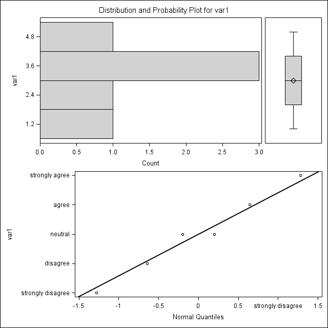

| this is footnote 1 |
| --- |
| this is footnote 2 |
| this is footnote 3 |

| Univariate Report for var 1 in dataA2 |
| --- |
| Report by Melinda Higgins |
| dated 09/15/2017 |

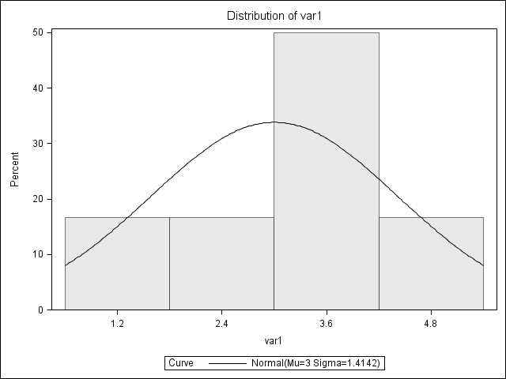

| this is footnote 1 |
| --- |
| this is footnote 2 |
| this is footnote 3 |

| Univariate Report for var 1 in dataA2 |
| --- |
| Report by Melinda Higgins |
| dated 09/15/2017 |

Fitted Normal Distribution for var1

| Parameters for Normal Distribution Parameter | Parameters for Normal Distribution Symbol | Parameters for Normal Distribution Estimate |
| --- | --- | --- |
| Mean | Mu | 3 |
| Std Dev | Sigma | 1.414214 |

| Goodness-of-Fit Tests for Normal Distribution Test | Goodness-of-Fit Tests for Normal Distribution Statistic | Goodness-of-Fit Tests for Normal Distribution Statistic | Goodness-of-Fit Tests for Normal Distribution p Value | Goodness-of-Fit Tests for Normal Distribution p Value |
| --- | --- | --- | --- | --- |
| Kolmogorov-Smirnov | D | 0.16666667 | Pr > D | >0.150 |
| Cramer-von Mises | W-Sq | 0.02803177 | Pr > W-Sq | >0.250 |
| Anderson-Darling | A-Sq | 0.17100986 | Pr > A-Sq | >0.250 |

| Quantiles for Normal Distribution Percent | Quantiles for Normal Distribution Quantile Observed | Quantiles for Normal Distribution Quantile Estimated |
| --- | --- | --- |
| 1.0 | 1.00000 | -0.28995 |
| 5.0 | 1.00000 | 0.67383 |
| 10.0 | 1.00000 | 1.18761 |
| 25.0 | 2.00000 | 2.04613 |
| 50.0 | 3.00000 | 3.00000 |
| 75.0 | 4.00000 | 3.95387 |
| 90.0 | 5.00000 | 4.81239 |
| 95.0 | 5.00000 | 5.32617 |
| 99.0 | 5.00000 | 6.28995 |

| this is footnote 1 |
| --- |
| this is footnote 2 |
| this is footnote 3 |

[output not shown]

## Recoding

Suppose we want to recode `var1` into a new variable identifying subjects with `var1` scores <=3 and those >3 (splitting the data at 3). We’ll create the new variable and then add the formatting we want using the `factor()` function in `R`.

Since we made `var1` a “factor” type variable above, we have to use the `as.numeric()` function to be able to manipulate the numeric values underlying this variable as a factor.

We also use the `as.numeric()` function again since the statement `x > 3` is a logic statement and returns `FALSE` and `TRUE` and what we want is `0` and `1`. If you do want a logic variable you can leave off this 2nd (outer) `as.numeric()` function.

**R Code**

```r
x <- c(1,2,3,4,5)
x > 3
```

```
[1] FALSE FALSE FALSE  TRUE  TRUE
```

```r
typeof(x > 3)
```

```
[1] "logical"
```

```r
dataA$var1r <- as.numeric(
  as.numeric(dataA$var1) > 3
  )

typeof(dataA$var1r)
```

```
[1] "double"
```

```r
dataA$var1r <- factor(dataA$var1r,
                      levels=c(0,1),
                      labels=c("NO var1 <= 3",
                               "YES var1 > 3"))

kable(dataA)
```

| id | var1 | var2 | var3 | var1r |
| --- | --- | --- | --- | --- |
| 1 | neutral | male | 45 | NO var1 <= 3 |
| 2 | neutral | male | 44 | NO var1 <= 3 |
| 3 | disagree | female | 34 | NO var1 <= 3 |
| 5 | agree | female | 38 | YES var1 > 3 |
| 8 | strongly disagree | male | 41 | NO var1 <= 3 |
| 9 | strongly agree | female | 39 | YES var1 > 3 |

**SAS Code**

From lesson 5 - merge `dataA` and `dataB` together.

```
data dataAB;
  set dataA dataB;
run;

proc print data=dataAB noobs; run;
```

| id | var1 | var2 | var3 | VAR4 |
| --- | --- | --- | --- | --- |
| 1 | 3 | m | 45 | . |
| 2 | 3 | m | 44 | . |
| 3 | 2 | f | 34 | . |
| 5 | 4 | f | 38 | . |
| 8 | 1 | m | 41 | . |
| 9 | 5 | f | 39 | . |
| 11 | 4 | f | . | 0 |
| 12 | 4 | m | . | 6 |
| 14 | 2 | m | . | 4 |
| 15 | 3 | f | . | 7 |
| 17 | 1 | f | . | 8 |
| 18 | 5 | m | . | 5 |

Let’s recode `var1` into a new variable identifying subjects with `var1` scores <=3 and those >3 (splitting the data at 3). First we’ll define the formatting we want for our new variable and after we recode it in the `DATA` step we’ll apply the formatting.

```
proc format;
  value splitYN
    0 = 'NO var1 <= 3'
    1 = 'YES var1 > 3';
run;
```

Create new dataset with recoded variables and apply new format labels.

```
data dataAB_new;
  set dataAB;
  if var1 > 3 then var1split3 = 1;
  else             var1split3 = 0;
  format var1split3 splitYN.;
run;
```

Create table and plot of new variable split <=3 and >3.

```
proc freq data=dataAB_new;
 tables var1split3/plots=freqplot;
 run;
```

| var1split3 | Frequency | Percent | Cumulative Frequency | Cumulative Percent |
| --- | --- | --- | --- | --- |
| NO var1 <= 3 | 7 | 58.33 | 7 | 58.33 |
| YES var1 > 3 | 5 | 41.67 | 12 | 100.00 |

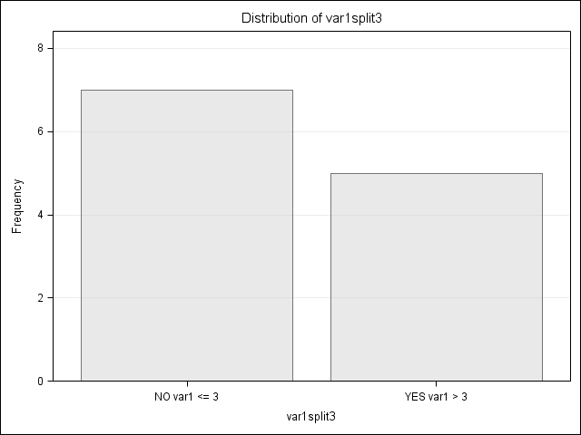